# Moneyball

```r
library(caret)
library(corrplot)
library(dplyr)
library(mice) # will be used to impute missing values
library(VIM)
```

```r
# browse to the data
moneyball = read.csv('/Users/legs_jorge/Documents/Data Science Projects/MSDS_Northwestern/MSDS 411/Unit 01 Moneyball Baseball Problem/Data/moneyball.csv', header = T)
```

Let’s do a quick analysis to understand the distribution of NA values accross our dataset. Let’s sort the fields with most NAs from high to low..

```r
#let check for NAs in the data
#Counting the number of NAs per column and check the percentage of NAs per column
NAPerc <- sapply(moneyball, function(x) (sum(is.na(x))/length(x))*100) %>%
  data.frame()
NAPerc$Column <- rownames(NAPerc)
colnames(NAPerc) <- c("NA_Perc", "Col_Name")
subset(NAPerc,NA_Perc > 0) %>% arrange(desc(NA_Perc))
```

| NA_Perc | Col_Name |
| --- | --- |
| 91.608084 | TEAM_BATTING_HBP |
| 33.919156 | TEAM_BASERUN_CS |
| 12.565905 | TEAM_FIELDING_DP |
| 5.755712 | TEAM_BASERUN_SB |
| 4.481547 | TEAM_BATTING_SO |
| 4.481547 | TEAM_PITCHING_SO |

```
Click in a column to sort by the corresponding variable.
To regain use of the VIM GUI and the R console, click outside the plot region.
```

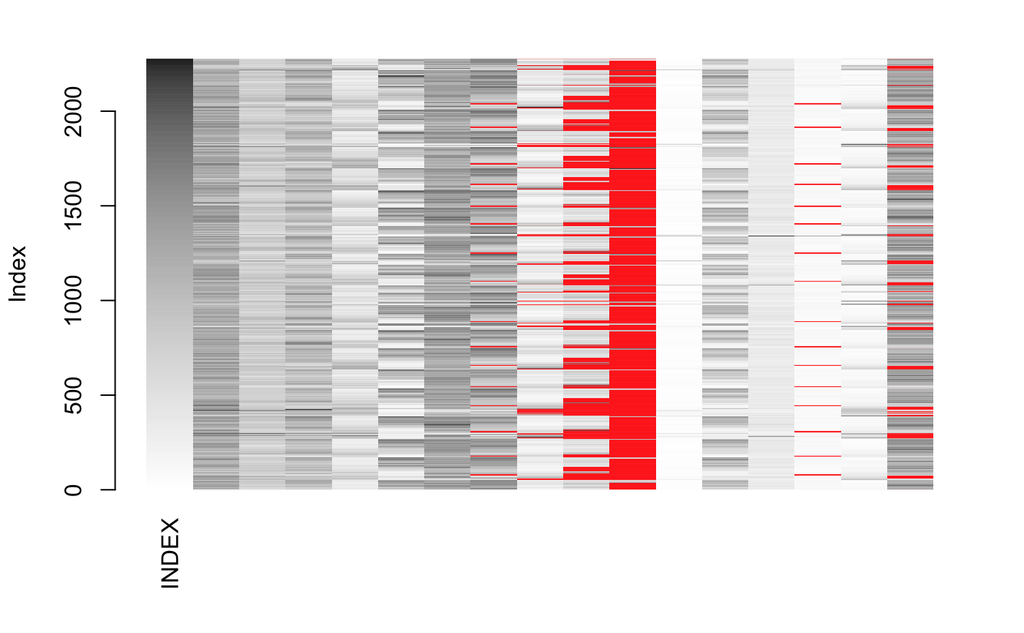

```r
matrixplot(moneyball)
```

It’s clear that TEAM_BATTING_HBP is going to be a problematic column with 92% of the data missing. Before we start the imputation, let’s try to understand why we have missing data.

**There are two types of missing data**

- *MCAR*: missing completely at random. This is the desirable scenario in case of missing data.
- *MNAR*: missing not at random. Missing not at random data is a more serious issue and in this case it might be wise to check the data gathering process further and try to understand why the information is missing. For instance, if most of the people in a survey did not answer a certain question, why did they do that? Was the question unclear?  
  It would be good to understand exactly what type of missing value we are dealing with.

Let’s use the `mice` package to help us understant how all the NAs behave in the data. `mice` provides a handy function called `md.pattern` that allows one to understand the pattern of missing data. Hopefully by looking at the pattern, we can have an idea on why the data could be missing.

```r
md.pattern(moneyball) %>% data.frame()
```

|  | INDEX | TARGET_WINS | TEAM_BATTING_H | TEAM_BATTING_2B | TEAM_BATTING_3B | TEAM_BATTING_HR | TEAM_BATTING_BB | TEAM_PITCHING_H | TEAM_PITCHING_HR | TEAM_PITCHING_BB | TEAM_FIELDING_E | TEAM_BATTING_SO | TEAM_PITCHING_SO | TEAM_BASERUN_SB | TEAM_FIELDING_DP | TEAM_BASERUN_CS | TEAM_BATTING_HBP | V18 |
| --- | --- | --- | --- | --- | --- | --- | --- | --- | --- | --- | --- | --- | --- | --- | --- | --- | --- | --- |
| 191 | 1 | 1 | 1 | 1 | 1 | 1 | 1 | 1 | 1 | 1 | 1 | 1 | 1 | 1 | 1 | 1 | 1 | 0 |
| 1295 | 1 | 1 | 1 | 1 | 1 | 1 | 1 | 1 | 1 | 1 | 1 | 1 | 1 | 1 | 1 | 1 | 0 | 1 |
| 349 | 1 | 1 | 1 | 1 | 1 | 1 | 1 | 1 | 1 | 1 | 1 | 1 | 1 | 1 | 1 | 0 | 0 | 2 |
| 18 | 1 | 1 | 1 | 1 | 1 | 1 | 1 | 1 | 1 | 1 | 1 | 1 | 1 | 1 | 0 | 1 | 0 | 2 |
| 53 | 1 | 1 | 1 | 1 | 1 | 1 | 1 | 1 | 1 | 1 | 1 | 1 | 1 | 0 | 1 | 0 | 0 | 3 |
| 190 | 1 | 1 | 1 | 1 | 1 | 1 | 1 | 1 | 1 | 1 | 1 | 1 | 1 | 1 | 0 | 0 | 0 | 3 |
| 102 | 1 | 1 | 1 | 1 | 1 | 1 | 1 | 1 | 1 | 1 | 1 | 0 | 0 | 1 | 1 | 0 | 0 | 4 |
| 78 | 1 | 1 | 1 | 1 | 1 | 1 | 1 | 1 | 1 | 1 | 1 | 1 | 1 | 0 | 0 | 0 | 0 | 4 |
|  | 0 | 0 | 0 | 0 | 0 | 0 | 0 | 0 | 0 | 0 | 0 | 102 | 102 | 131 | 286 | 772 | 2085 | 3478 |

The **first column** of the output shows the number of unique missing data patterns. There are 191 observations with nonmissing values, and there are 1295 observations with nonmissing values except for the variable TEAM_BATTING_HBP. The **rightmost column** shows the number of *missing variables* in a particular missing pattern. For example, the first row has no missing value and it is “0” in the row. The **last row** counts the number of missing values for each variable. For example, the variable TEAM_PITCHING_BB contains no missing values and the variable TEAM_BATTING_SO contains 102 missing values. This table can be helpful when you decide to drop some observations with missing variables exceeding a preset threshold.

After doing some reading it looks like that columns could be translated to a 0 or 1. I need to do more investigating. From working experience, usually columns with high volumes of NAs indicates important informations, simply because they could be capturing rare instance where a process fails. Instead of deleting it, I will try to see if I can transform it into a categorical variable with 1s and 0s. Now, regarding the other one, I will try some other inputation methods such as KNN, mean, median, etc. [Here](https://www.r-bloggers.com/imputing-missing-data-with-r-mice-package/) is a great article from Rblogger that discusses the package [MICE](https://cran.r-project.org/web/packages/mice/mice.pdf).

```
Call:corCi(x = x, keys = keys, n.iter = n.iter, p = p, overlap = overlap,
    poly = poly, method = method, plot = plot, minlength = minlength)

 Coefficients and bootstrapped confidence intervals
                 INDEX TARGE TEAM_BATTING_H TEAM_BATTING_2 TEAM_BATTING_3 TEAM_BATTING_HR TEAM_BATTING_B
INDEX             1.00
TARGET_WINS      -0.01  1.00
TEAM_BATTING_H    0.00  0.37  1.00
TEAM_BATTING_2B   0.02  0.24  0.60           1.00
TEAM_BATTING_3B   0.00  0.12  0.33          -0.16           1.00
TEAM_BATTING_HR   0.05  0.16  0.07           0.44          -0.68           1.00
TEAM_BATTING_BB  -0.04  0.23  0.07           0.27          -0.28           0.49            1.00
TEAM_BATTING_SO   0.09 -0.08 -0.40           0.17          -0.72           0.73            0.26
TEAM_BASERUN_SB   0.06  0.11  0.00          -0.16           0.36          -0.42           -0.15
TEAM_BASERUN_CS   0.02 -0.01  0.02          -0.02           0.20          -0.37           -0.17
TEAM_BATTING_HBP  0.06  0.04 -0.03           0.02          -0.17           0.08            0.01
TEAM_PITCHING_H  -0.01  0.21  0.75           0.28           0.54          -0.30           -0.14
TEAM_PITCHING_HR  0.05  0.17  0.11           0.46          -0.65           0.98            0.46
TEAM_PITCHING_BB -0.04  0.21  0.15           0.22          -0.10           0.28            0.87
TEAM_PITCHING_SO  0.09 -0.09 -0.37           0.11          -0.60           0.57            0.12
TEAM_FIELDING_E  -0.03 -0.12  0.11          -0.38           0.74          -0.81           -0.43
TEAM_FIELDING_DP  0.01 -0.05  0.18           0.25          -0.25           0.39            0.32
                 TEAM_BATTING_S TEAM_BASERUN_S TEAM_BASERUN_C TEAM_BATTING_HB TEAM_PITCHING_H
INDEX
TARGET_WINS
TEAM_BATTING_H
TEAM_BATTING_2B
TEAM_BATTING_3B
TEAM_BATTING_HR
TEAM_BATTING_BB
TEAM_BATTING_SO   1.00
TEAM_BASERUN_SB  -0.11           1.00
TEAM_BASERUN_CS  -0.17           0.67           1.00
TEAM_BATTING_HBP  0.17          -0.03          -0.06           1.00
TEAM_PITCHING_H  -0.60           0.14           0.02          -0.02            1.00
TEAM_PITCHING_HR  0.69          -0.41          -0.36           0.08           -0.21
TEAM_PITCHING_BB  0.06          -0.02          -0.13           0.01            0.14
TEAM_PITCHING_SO  0.90          -0.06          -0.16           0.18           -0.37
TEAM_FIELDING_E  -0.74           0.36           0.21           0.07            0.47
TEAM_FIELDING_DP  0.09          -0.42          -0.14          -0.07            0.04
```

[output cut: 145 more lines]

```
TEAM_PITCHING_H-TEAM_PITCHING_HR     -0.25      -0.25    -0.21      -0.17     -0.17 0.00
TEAM_PITCHING_H-TEAM_PITCHING_B       0.09       0.09     0.14       0.19      0.18 0.00
TEAM_PITCHING_H-TEAM_PITCHING_S      -0.41      -0.41    -0.37      -0.33     -0.33 0.00
TEAM_PITCHING_H-TEAM_FIELDING_E       0.42       0.43     0.47       0.51      0.50 0.00
TEAM_PITCHING_H-TEAM_FIELDING_D      -0.02      -0.02     0.04       0.08      0.08 0.22
TEAM_PITCHING_HR-TEAM_PITCHING_B      0.28       0.28     0.32       0.36      0.36 0.00
TEAM_PITCHING_HR-TEAM_PITCHING_S      0.55       0.55     0.59       0.62      0.62 0.00
TEAM_PITCHING_HR-TEAM_FIELDING_E     -0.78      -0.78    -0.77      -0.75     -0.75 0.00
TEAM_PITCHING_HR-TEAM_FIELDING_D      0.34       0.34     0.39       0.44      0.43 0.00
TEAM_PITCHING_B-TEAM_PITCHING_S       0.00       0.00     0.04       0.09      0.08 0.03
TEAM_PITCHING_B-TEAM_FIELDING_E      -0.23      -0.23    -0.19      -0.15     -0.16 0.00
TEAM_PITCHING_B-TEAM_FIELDING_D       0.22       0.22     0.27       0.31      0.30 0.00
TEAM_PITCHING_S-TEAM_FIELDING_E      -0.60      -0.60    -0.56      -0.52     -0.52 0.00
TEAM_PITCHING_S-TEAM_FIELDING_D      -0.03      -0.03     0.01       0.06      0.06 0.49
TEAM_FIELDING_E-TEAM_FIELDING_D      -0.41      -0.41    -0.37      -0.33     -0.33 0.00
```

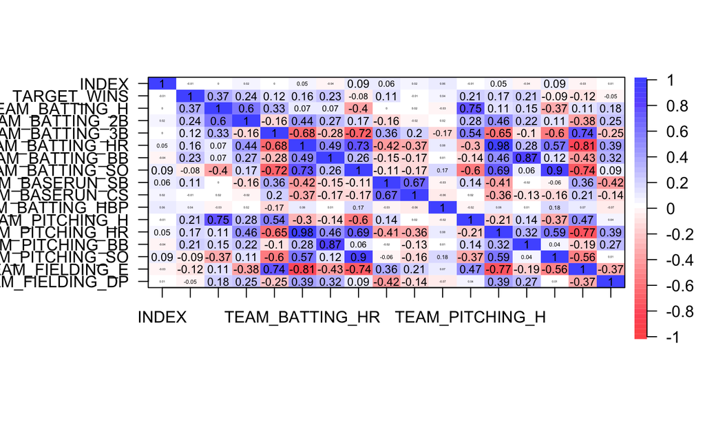

```r
cor.ci(moneyball, method="spearman")
```

- [Missing data exploration: highlighting graphical presentation of missing pattern](https://www.ncbi.nlm.nih.gov/pmc/articles/PMC4701517/)